# Generate *high density* simulated spatial transcriptomic dataset from scRNA-seq dataset

Ningshan Li & Yunqing Liu

2024/05/16

# 1 Version

```r
version[['version.string']]
```

```
[1] "R version 4.2.2 Patched (2022-11-10 r83330)"
```

# 2 Load manually cruated STARmap dataset

This **single-cell resolution** spatial transcriptomics dataset contains two independent experiments on **mouse primary visual cortex** ( [publication](https://www.science.org/doi/10.1126/science.aat5691)), and both experiments are included in our analysis. The physical locations and gene expression profiles (raw nUMIs) of the selected cells are manually curated and saved into a R object [`CoarseGrain_Data.rds`](https://github.com/az7jh2/SDePER_Analysis/blob/main/Simulation/Generate_simulation_data/CoarseGrain_Data.rds). After loading data, it’s a list containing the meta data (in slot `meta`) and gene raw nUMI (in slot `count`).

Columns in meta data:

- `index`: cell barcode
- `dat`: 1 or 2, indicating cell is from 1st or 2nd experiment
- `cluster_name`: cell type annotation
- `X`, `Y`: physical locations (in pixels) of cells. We manually add a **4500 pixels offset** on `X` coordinate of cells from 1st experiment

We just use the spatial location and cell type annotation in meta data.

```r
file_name = file.path(home.dir, 'CoarseGrain_Data.rds')
org_data = readRDS(file_name)
meta_data = org_data$meta
gene_count = org_data$count
rm(org_data)
print(sprintf('load data from %s', file_name))
```

```
[1] "load data from /home/hill103/Documents/Spatial/Simulation_seq_based/Generate_high_density_simulation_data/CoarseGrain_Data.rds"
```

```r
# first 12 gene names need to exclude the first Character "X"
for (i in 1:12) {
  colnames(gene_count)[i] = substr(colnames(gene_count)[i], 2, nchar(colnames(gene_count)[i]))
}
```

We only include **2,002 cells** across **12 cell types** which overlaps with the paired reference scRNA-seq dataset. **No further filtering on genes or cells**!

```r
print(sprintf('total %d cells, %d genes', nrow(gene_count), ncol(gene_count)))
```

```
[1] "total 2002 cells, 1020 genes"
```

Number of cells of each select cell type is shown as below.

```r
stopifnot(all(meta_data$index == row.names(gene_count)))

table(as.character(meta_data$cluster_name))
```

```
Astro eL2/3   eL4   eL5   eL6  Endo Micro Oligo PVALB   Smc   SST   VIP
  259   292   327   110   368   134    69   278    61    42    33    29
```

# 3 Process scRNA-seq data for generating simulation data

## 3.1 Load data

For the generation of sequencing-based simulation data, we utilized a scRNA-seq dataset from the **mouse visual cortex**, acquired using the **inDrop** technique (GSE102827).

- Raw nUMI counts of 25,187 genes in 65,539 cells: [GSE102827_merged_all_raw.csv.gz](https://www.ncbi.nlm.nih.gov/geo/download/?acc=GSE102827&format=file&file=GSE102827%5Fmerged%5Fall%5Fraw%2Ecsv%2Egz)
- Cell type annotation of 65,539 cells: [GSE102827_cell_type_assignments.csv.gz](https://www.ncbi.nlm.nih.gov/geo/download/?acc=GSE102827&format=file&file=GSE102827%5Fcell%5Ftype%5Fassignments%2Ecsv%2Egz)

```r
sc_count = read.csv(file.path(home.dir, 'GSE102827_merged_all_raw.csv'), row.names = 1, check.names = F)
print(sprintf('total %d cells, %d genes', ncol(sc_count), nrow(sc_count)))
```

```
[1] "total 65539 cells, 25187 genes"
```

```r
sc_meta = read.csv(file.path(home.dir, 'GSE102827_cell_type_assignments.csv'), row.names = 1, check.names = F)
print(sprintf('annotation for %d cells', nrow(sc_meta)))
```

```
[1] "annotation for 65539 cells"
```

## 3.2 Select cells and curate cell type annotation

We select cells with the **12 cell types** included in study, then rename the cell type names to be consistent with spatial data.

```r
sc_meta = sc_meta[!is.na(sc_meta$celltype), ]

# rename cell type names
sc_meta[grep("SM", sc_meta$celltype), 'celltype'] = "Smc"
sc_meta[grep("Endo", sc_meta$celltype), 'celltype'] = "Endo"
sc_meta[grep("Olig", sc_meta$celltype), 'celltype'] = "Oligo"
sc_meta[grep("ExcL23", sc_meta$celltype), 'celltype'] = "eL2/3"
sc_meta[grep("ExcL4", sc_meta$celltype), 'celltype'] = "eL4"
sc_meta[grep("ExcL5_", sc_meta$celltype), 'celltype'] = "eL5"
sc_meta[grep("ExcL6", sc_meta$celltype), 'celltype'] = "eL6"
sc_meta[grep("Micro", sc_meta$celltype), 'celltype'] = "Micro"
sc_meta[grep("Int_Pv", sc_meta$celltype), 'celltype'] = "PVALB"
sc_meta[grep("Int_Sst", sc_meta$celltype), 'celltype'] = "SST"
sc_meta[grep("Int_Vip",sc_meta$celltype), 'celltype'] = "VIP"

# remove cells of other cell types
sc_meta = sc_meta[sc_meta$celltype %notin% c("Int_Cck", "Int_Npy", "Macrophage", "Hip", "OPC_1", "OPC_2", "Pericyte", "RSP", "Sub"), ]

print(sprintf('remain %d cells', nrow(sc_meta)))
```

```
[1] "remain 43836 cells"
```

```r
print(table(sc_meta$celltype))
```

```
Astro eL2/3   eL4   eL5   eL6  Endo Micro Oligo PVALB   Smc   SST   VIP
 7039  2963  3198  3793  3276  3450 10158  8630   227   621   355   126
```

# 4 Replace gene expression profiles of STARmap cells with scRNA-seq cells

NOTE: we keep ALL genes.

For *PVALB* and *VIP*, if there are not enough cells in a specific cell type in GSE102827 scRNA-seq data for random sampling, we first include all available cells of that cell type multiple times to approach the required number of cells. Then, we randomly select the remaining number of cells needed from the available cells to meet the requirement.

NOTE: R will automatically add `.1`, `.2`, … for duplicated row names.

```r
# function to sample cells
sample_cells = function(cells, required_cells) {
  # Get the number of available cells
  available_cells = length(cells)

  if (available_cells >= required_cells) {
    # If enough cells are available, sample directly
    sampled_cells = sample(cells, required_cells, replace = FALSE)
  } else {
    # If not enough cells are available, include all available cells multiple times
    num_full_repeats = required_cells %/% available_cells
    remaining_cells = required_cells %% available_cells

    # Create a list of repeated cells
    repeated_cells = rep(cells, num_full_repeats)

    # Randomly select the remaining cells needed
    additional_cells = sample(cells, remaining_cells, replace = FALSE)

    # Combine the repeated cells and the additional cells
    sampled_cells = c(repeated_cells, additional_cells)
  }
  # finally shuffle all cells
  return(sample(sampled_cells))
}


# data after replacement for generating simulation data
processed_count_3x = c()
processed_meta_3x = c()
processed_count_6x = c()
processed_meta_6x = c()

for (one_celltype in sort(unique(sc_meta$celltype))) {
  ori_select_meta = meta_data[meta_data$cluster_name==one_celltype, c("X", "Y", "cluster_name", "index")]
  ncell = nrow(ori_select_meta) # number of cells in STARmap data for that cell type

  # 3x setting
  multiply_num = 3
  select_cell = sample_cells(row.names(sc_meta[sc_meta$celltype==one_celltype, ]), multiply_num*ncell)
  # keep all genes, note to transpose it as rows as cells and columns as genes
  processed_count_3x = rbind(processed_count_3x, t(sc_count[, select_cell]))
  # replace cell barcodes
  select_meta = ori_select_meta[rep(1:nrow(ori_select_meta), multiply_num), ]
  select_meta$index = select_cell
  processed_meta_3x = rbind(processed_meta_3x, select_meta)

  # 6x setting
  multiply_num = 6
  select_cell = sample_cells(row.names(sc_meta[sc_meta$celltype==one_celltype, ]), multiply_num*ncell)
  # keep all genes, note to transpose it as rows as cells and columns as genes
  processed_count_6x = rbind(processed_count_6x, t(sc_count[, select_cell]))
  # replace cell barcodes
  select_meta = ori_select_meta[rep(1:nrow(ori_select_meta), multiply_num), ]
  select_meta$index = select_cell
  processed_meta_6x = rbind(processed_meta_6x, select_meta)

}

processed_count_3x = as.data.frame(processed_count_3x)
stopifnot(all(row.names(processed_count_3x) == processed_meta_3x$index))

processed_count_6x = as.data.frame(processed_count_6x)
# add .1 to cell barcode in meta data
for (i in 1:nrow(processed_count_6x)) {
  if (processed_meta_6x[i, 'cluster_name'] %in% c('PVALB', 'VIP')) {
    if (row.names(processed_count_6x)[i] != processed_meta_6x[i, 'index']) {
      stopifnot(unlist(strsplit(row.names(processed_count_6x)[i], '\\.'))[1] == processed_meta_6x[i, 'index'])
      processed_meta_6x[i, 'index'] = row.names(processed_count_6x)[i]
    }
  }
}
stopifnot(all(row.names(processed_count_6x) == processed_meta_6x$index))

print('3x Setting:')
```

```
[1] "3x Setting:"
```

```r
print(sprintf('get %d cells, %d genes', nrow(processed_count_3x), ncol(processed_count_3x)))
```

```
[1] "get 6006 cells, 25187 genes"
```

```r
print(table(as.character(processed_meta_3x$cluster_name)))
```

```
Astro eL2/3   eL4   eL5   eL6  Endo Micro Oligo PVALB   Smc   SST   VIP
  777   876   981   330  1104   402   207   834   183   126    99    87
```

```r
print('6x Setting:')
```

```
[1] "6x Setting:"
```

```r
print(sprintf('get %d cells, %d genes', nrow(processed_count_6x), ncol(processed_count_6x)))
```

```
[1] "get 12012 cells, 25187 genes"
```

```r
print(table(as.character(processed_meta_6x$cluster_name)))
```

```
Astro eL2/3   eL4   eL5   eL6  Endo Micro Oligo PVALB   Smc   SST   VIP
 1554  1752  1962   660  2208   804   414  1668   366   252   198   174
```

# 5 Generate squre pseudo-spots by *coarse-graining*

We defined a square with **500×500** pixels (**~51.5 μm**) as one pseudo-spot, and all cells falling into this square area are considered as cells in this pseudo-spot.

In total we get **581** square pseudo-spots, and each square pseudo-spot contains 1 to at most 12 cells (at most 6 different cell types)

The nUMI count of gene $j$ for a given pseudo-spot consisting of cells $i=1,…,n$ are defined as:
$$nUMI_j=\frac{∑_i^n (x_{ij}/N_i)} {n}
)×1,000$$
where $x_{ij}$ is nUMI of gene $j$ for cell $i$ and $N_i$ is the sequencing depth (sum of nUMI of all genes) of cell $i$.

```r
#dat:meta.data for cell-level spatial data; count:data.frame of count data for cell-level spatial data
create_grid<-function(dat,count,x="X",y="Y",index="index",cluster="louvain",breaks=200){
    seq_depth<-rowSums(count)
    if(is.factor(dat[,cluster])){dat[,cluster]<-factor(dat[,cluster])}
    range_x<-range(dat[,x])
    range_y<-range(dat[,y])
    x_start<-floor(range_x[1])
    x_end<-ceiling(range_x[2])
    grid_x<-seq(x_start,x_end,breaks)
    y_start<-floor(range_y[1])
    y_end<-ceiling(range_y[2])
    grid_y<-seq(y_start,y_end,breaks)
    grid_table<-ct_table<-data.frame(ncell=numeric(),x=numeric(),y=numeric())
    #grid_table<-matrix(0,nrow=length(grid_y),ncol=length(grid_x))
    ct_table<-grid_table
    spot_exp<-list()
    #rownames(grid_table)<-grid_y
    #colnames(grid_table)<-grid_x
    if(max(grid_x)<x_end){grid_x<-c(grid_x,max(grid_x)+breaks)}
    if(max(grid_y)<y_end){grid_y<-c(grid_y,max(grid_y)+breaks)}
    ncell_fov<-nrow(dat)
    for(i in 1:(length(grid_y)-1)){
        for(j in 1:(length(grid_x)-1)){
            fall_id<-which(dat[,x]>=grid_x[j] & dat[,x]<grid_x[j+1] & dat[,y]>=grid_y[i] & dat[,y]<grid_y[i+1])
            grid_table<-rbind(grid_table,c(ncell=length(fall_id),x=grid_x[j],y=grid_y[i]))
            ct_table<-rbind(ct_table,c(nct=length(unique(dat[fall_id,cluster])),x=grid_x[j],y=grid_y[i]))
            spot_exp<-c(spot_exp,list(ceiling(colSums(count[dat[fall_id,index],]/(seq_depth[dat[fall_id,index]]*length(fall_id))*scaler))))
            names(spot_exp)[length(spot_exp)]<-paste0("x",grid_x[j],"y",grid_y[i])
            tmp_prop<-data.frame(cbind(t(as.matrix(table(dat[fall_id,cluster])/sum(table(dat[fall_id,cluster])),nrow=1,drop=F)),x=grid_x[j],y=grid_y[i]))
            if(i==1&j==1){grid_prop=tmp_prop}else(grid_prop=rbind(grid_prop,tmp_prop))
        }
    }
    colnames(grid_table)<-c("ncell","x","y")
    colnames(ct_table)<-c("nct","x","y")
    spot_exp_mat<-Reduce(cbind,spot_exp)
    colnames(spot_exp_mat)<-names(spot_exp)
    nonempty_cell<-which(grid_table$ncell!=0)
    grid_table=grid_table[nonempty_cell,]
    ct_table=ct_table[nonempty_cell,]
    grid_prop=grid_prop[nonempty_cell,]
    spot_exp_mat=spot_exp_mat[,nonempty_cell]
    return(list(ncell_grid=grid_table,nct_grid=ct_table,prop_grid=grid_prop,spatial_exp=spot_exp_mat))
}

# spatial_exp is the generated coarse graining expression data
scaler = 1000
grid_l = 500


start_time = Sys.time()
sim_res_3x = create_grid(processed_meta_3x, processed_count_3x, cluster="cluster_name", breaks=grid_l)
sim_res_6x = create_grid(processed_meta_6x, processed_count_6x, cluster="cluster_name", breaks=grid_l)
end_time = Sys.time()
print(end_time-start_time)
```

```
Time difference of 1.394571 hours
```

NOTE: **Locations**, **cell type proportions** and **Adjacency Matrix** of simulated pseudo-spots are kept identical as [STARmap-based simulation data](https://github.com/az7jh2/SDePER_Analysis/blob/main/Simulation).

# 6 Save generated simulated spatial dataset

## 6.1 Save nUMI counts of all genes of spatial pseudo-spots

nUMI count of all genes are stored in `sim_res_3x$spatial_exp` and `sim_res_6x$spatial_exp`, and rows as genes, columns as pseudo-spots. We transpose this matrix into **rows as pseudo-spots and columns as genes**, then save into file [`sim_seq_based_3x_spatial_spot_nUMI.csv`](https://github.com/az7jh2/SDePER_Analysis/blob/main/Simulation_seq_based/Generate_high_density_simulation_data/sim_seq_based_3x_spatial_spot_nUMI.csv) and [`sim_seq_based_6x_spatial_spot_nUMI.csv`](https://github.com/az7jh2/SDePER_Analysis/blob/main/Simulation_seq_based/Generate_high_density_simulation_data/sim_seq_based_6x_spatial_spot_nUMI.csv), respectively.

```r
to_save = t(sim_res_3x$spatial_exp)
file_name = 'sim_seq_based_3x_spatial_spot_nUMI.csv'
write.csv(to_save, file_name)
print(sprintf('save %d gene nUMIs of %d simulated spatial pseudo-spots into file %s', ncol(to_save), nrow(to_save), file_name))
```

```
[1] "save 25187 gene nUMIs of 581 simulated spatial pseudo-spots into file sim_seq_based_3x_spatial_spot_nUMI.csv"
```

```r
to_save = t(sim_res_6x$spatial_exp)
file_name = 'sim_seq_based_6x_spatial_spot_nUMI.csv'
write.csv(to_save, file_name)
print(sprintf('save %d gene nUMIs of %d simulated spatial pseudo-spots into file %s', ncol(to_save), nrow(to_save), file_name))
```

```
[1] "save 25187 gene nUMIs of 581 simulated spatial pseudo-spots into file sim_seq_based_6x_spatial_spot_nUMI.csv"
```

## 6.2 Save number of cells per spot

Number of cells per synthesized spot are stored in `sim_res_3x$ncell_grid` and `sim_res_6x$ncell_grid`. then saved into file [`sim_seq_based_3x_spatial_spot_ncell.csv`](https://github.com/az7jh2/SDePER_Analysis/blob/main/Simulation_seq_based/Generate_high_density_simulation_data/sim_seq_based_3x_spatial_spot_ncell.csv) and [`sim_seq_based_6x_spatial_spot_ncell.csv`](https://github.com/az7jh2/SDePER_Analysis/blob/main/Simulation_seq_based/Generate_high_density_simulation_data/sim_seq_based_6x_spatial_spot_ncell.csv), respectively.

```r
to_save = sim_res_3x$ncell_grid
file_name = 'sim_seq_based_3x_spatial_spot_ncell.csv'
row.names(to_save) = paste0('x', to_save$x, 'y', to_save$y)
to_save = to_save[, !(colnames(to_save) %in% c('x', 'y')), drop=F]
colnames(to_save) = 'nCell'
write.csv(to_save, file_name)
print(sprintf('save number of cells in %d simulated spatial spots into file %s', nrow(to_save), file_name))
```

```
[1] "save number of cells in 581 simulated spatial spots into file sim_seq_based_3x_spatial_spot_ncell.csv"
```

```r
to_save = sim_res_6x$ncell_grid
file_name = 'sim_seq_based_6x_spatial_spot_ncell.csv'
row.names(to_save) = paste0('x', to_save$x, 'y', to_save$y)
to_save = to_save[, !(colnames(to_save) %in% c('x', 'y')), drop=F]
colnames(to_save) = 'nCell'
write.csv(to_save, file_name)
print(sprintf('save number of cells in %d simulated spatial spots into file %s', nrow(to_save), file_name))
```

```
[1] "save number of cells in 581 simulated spatial spots into file sim_seq_based_6x_spatial_spot_ncell.csv"
```

## 6.3 Save cell type annotation of GSE102827 scRNA-seq cells

NOTE: we only keep those selected cells which were used for generating this simulation data, and use it as Internal Reference for cell type deconvolution in Sequencing-based Simulation Analysis. We also exclude duplicated cells for reference.

Cell type annotation of those selected cells are stored in `processed_meta_3x$cluster_name` and `processed_meta_6x$cluster_name`, and saved into file [`GSE102827_3x_scRNA_cell_celltype.csv`](https://github.com/az7jh2/SDePER_Analysis/blob/main/Simulation_seq_based/Run_SDePER_on_high_density_simulation_data/Scenario_1/ref_spatial/GSE102827_3x_scRNA_cell_celltype.csv) and [`GSE102827_6x_scRNA_cell_celltype.csv`](https://github.com/az7jh2/SDePER_Analysis/blob/main/Simulation_seq_based/Run_SDePER_on_high_density_simulation_data/Scenario_1/ref_spatial/GSE102827_6x_scRNA_cell_celltype.csv).

```r
to_save = processed_meta_3x[, c('cluster_name', 'index')]
file_name = 'GSE102827_3x_scRNA_cell_celltype.csv'
for (i in 1:nrow(to_save)) {
  to_save[i, 'index'] = unlist(strsplit(to_save[i, 'index'], '\\.'))[1]
}
to_save = unique(to_save)
row.names(to_save) = to_save$index
to_save = to_save[, 'cluster_name', drop=F]
colnames(to_save) = 'celltype'
to_save$celltype = as.character(to_save$celltype)
write.csv(to_save, file_name)
print(sprintf('save cell type annotation of %d scRNA-seq cells into file %s', nrow(to_save), file_name))
```

```
[1] "save cell type annotation of 6006 scRNA-seq cells into file GSE102827_3x_scRNA_cell_celltype.csv"
```

```r
to_save = processed_meta_6x[, c('cluster_name', 'index')]
file_name = 'GSE102827_6x_scRNA_cell_celltype.csv'
for (i in 1:nrow(to_save)) {
  to_save[i, 'index'] = unlist(strsplit(to_save[i, 'index'], '\\.'))[1]
}
to_save = unique(to_save)
row.names(to_save) = to_save$index
to_save = to_save[, 'cluster_name', drop=F]
colnames(to_save) = 'celltype'
to_save$celltype = as.character(to_save$celltype)
write.csv(to_save, file_name)
print(sprintf('save cell type annotation of %d scRNA-seq cells into file %s', nrow(to_save), file_name))
```

```
[1] "save cell type annotation of 11825 scRNA-seq cells into file GSE102827_6x_scRNA_cell_celltype.csv"
```

# 7 Exploration

## 7.1 Load 1x data

Read original sequencing-based simulation data [`sim_seq_based_spatial_spot_nUMI.csv`](https://github.com/az7jh2/SDePER_Analysis/blob/main/Simulation_seq_based/Generate_simulation_data/sim_seq_based_spatial_spot_nUMI.csv), i.e. **1x setting**.

```r
file_name = 'sim_seq_based_spatial_spot_nUMI.csv'
ori_df = read.csv(file.path(home.dir, file_name), row.names = 1, check.names = F)
print(sprintf('read nUMI of %d spots and %d genes from file %s', nrow(ori_df), ncol(ori_df), file_name))
```

```
[1] "read nUMI of 581 spots and 25187 genes from file sim_seq_based_spatial_spot_nUMI.csv"
```

## 7.2 Histogram of sum of nUMIs per spot in different density settings

Sum nUMIs of all genes in one spot and draw histogram.

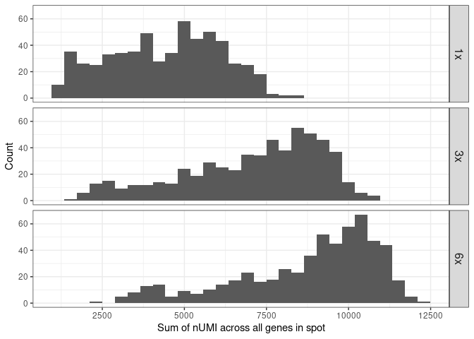

```r
plot_df = data.frame(setting=character(), sum=integer(), stringsAsFactors = F)
# 1x setting
tmp_vec = Matrix::rowSums(ori_df)
tmp_setting_vec = rep('1x', length(tmp_vec))
plot_df = rbind(plot_df, data.frame(setting=tmp_setting_vec, sum=tmp_vec, stringsAsFactors = F))
# 3x setting
tmp_vec = Matrix::colSums(sim_res_3x$spatial_exp)
tmp_setting_vec = rep('3x', length(tmp_vec))
plot_df = rbind(plot_df, data.frame(setting=tmp_setting_vec, sum=tmp_vec, stringsAsFactors = F))
# 6x setting
tmp_vec = Matrix::colSums(sim_res_6x$spatial_exp)
tmp_setting_vec = rep('6x', length(tmp_vec))
plot_df = rbind(plot_df, data.frame(setting=tmp_setting_vec, sum=tmp_vec, stringsAsFactors = F))

ggplot(plot_df, aes(x = sum)) +
  geom_histogram() +
  theme_bw() +
  theme(strip.text.y = element_text(size = 12)) +
  labs(x = 'Sum of nUMI across all genes in spot', y = 'Count') +
  facet_grid(rows = 'setting')
```

## 7.3 Histogram of #genes with nUMI>0 per spot in different density settings

Count the number of genes with nUMI>0 in one spot and draw histogram.

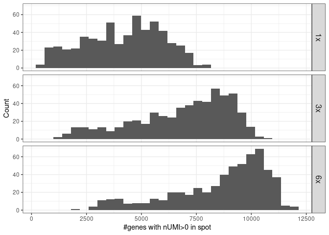

```r
plot_df = data.frame(setting=character(), sum=integer(), stringsAsFactors = F)
# 1x setting
tmp_vec = Matrix::rowSums(ori_df>0)
tmp_setting_vec = rep('1x', length(tmp_vec))
plot_df = rbind(plot_df, data.frame(setting=tmp_setting_vec, sum=tmp_vec, stringsAsFactors = F))
# 3x setting
tmp_vec = Matrix::colSums(sim_res_3x$spatial_exp>0)
tmp_setting_vec = rep('3x', length(tmp_vec))
plot_df = rbind(plot_df, data.frame(setting=tmp_setting_vec, sum=tmp_vec, stringsAsFactors = F))
# 6x setting
tmp_vec = Matrix::colSums(sim_res_6x$spatial_exp>0)
tmp_setting_vec = rep('6x', length(tmp_vec))
plot_df = rbind(plot_df, data.frame(setting=tmp_setting_vec, sum=tmp_vec, stringsAsFactors = F))

ggplot(plot_df, aes(x = sum)) +
  geom_histogram() +
  theme_bw() +
  theme(strip.text.y = element_text(size = 12)) +
  labs(x = '#genes with nUMI>0 in spot', y = 'Count') +
  facet_grid(rows = 'setting')
```